# Fine-tuning a model on a semantic role labeling task

notebook adapted from: https://github.com/huggingface/notebooks/blob/main/examples/token_classification.ipynb

Let's install the packages we need from 🤗 : Transformers, Datasets, Seqeval, and Evalaute, and all the necessary packages for preprocessing and evaluation.

**Please find the saved model and tokenizer at my Google Drive: https://drive.google.com/drive/folders/1sU6AvV9BIYBdBxMAKL3WGumLpFOY_4Rn?usp=sharing**

```python
from collections import Counter
from datasets import load_dataset
from evaluate import load
import pandas as pd
from datasets import Dataset
import numpy as np
from transformers import DataCollatorForTokenClassification
from transformers import set_seed
from transformers import AutoModelForTokenClassification, TrainingArguments, Trainer
import transformers
from transformers import AutoTokenizer
import matplotlib.pyplot as plt
from sklearn.metrics import classification_report, confusion_matrix, ConfusionMatrixDisplay
import pickle
import random
import seaborn as sns
from accelerate import Accelerator
accelerator = Accelerator()
```

```python
train = 'en_ewt-up-train.conllu'
dev = 'en_ewt-up-dev.conllu'
test = 'en_ewt-up-test.conllu'
```

## Duplication script for any number of predicates

```python
def create_dupfile_conllu(inputfile, outputfile, percentage=None):
    """
    Processes a CoNLL-U formatted dataset and duplicates sentences based on the number of predicates.
    Optionally truncates the dataset to keep a random subset of sentences.

    Parameters:
    inputfile (str): Path to a CoNLL-U formatted text file.
    outputfile (str): Path to a new file with duplicated sentences.
    percentage (float, optional): If provided, keeps only the specified percentage of sentences.
                                  Must be between 0 and 1. Default is None (keep all sentences).

    Ensures each predicate in the 11th column has its own instance of the sentence, keeping only the
    corresponding argument structure. The `# sent_id` and `# text` lines are retained for each duplicate.
    If a '# newdoc id' line appears, it is only written once at the start of its group.
    """

    with open(inputfile, 'r', encoding='utf-8') as file:
        lines = file.readlines()

    all_sentences = []
    current_sentence = []
    sent_metadata = []
    newdoc_id = None

    for line in lines:
        if line.startswith("# newdoc id"):
            newdoc_id = line.strip()
        elif line.startswith("#"):  # other metadata (# sent_id, # text)
            sent_metadata.append(line.strip())
        elif line.strip():  # token line
            current_sentence.append(line.strip().split("\t"))
        else:  # empty line (sentence boundary)
            if current_sentence:
                all_sentences.append((newdoc_id, sent_metadata, current_sentence))
            current_sentence = []
            sent_metadata = []
            newdoc_id = None

    # make sure that the last sentence is added if the file does not end with an empty line
    if current_sentence:
        all_sentences.append((newdoc_id, sent_metadata, current_sentence))

    # if subset is requested, do random sampling
    if percentage is not None:
        num_sentences = len(all_sentences)
        num_to_keep = max(1, int(num_sentences * percentage))
        all_sentences = random.sample(all_sentences, num_to_keep)

    output_lines = []

    # process each sentence and duplicate based on predicates
    for newdoc_id, sent_metadata, current_sentence in all_sentences:
        df = pd.DataFrame(current_sentence)
        df.columns = list(range(df.shape[1]))

        if df.shape[1] < 12:
            continue  # skip sentences without predicate/argument columns

        predicates = df[10].tolist()
        pred_indices = [i for i, p in enumerate(predicates) if p != '_']

        if not pred_indices:
            continue

        first_instance = True  # make sure '# newdoc id' appears only on the first version of the sentence

        for pred_idx in pred_indices:
            new_df = df.copy()

            # update predicate column, keep only the current predicate
            for i in range(len(new_df)):
                new_df.iloc[i, 10] = '_' if i != pred_idx else new_df.iloc[i, 10]

            arg_col = 11 + pred_indices.index(pred_idx)  # get correct argument column
            if arg_col < new_df.shape[1]:
                new_df[11] = new_df.iloc[:, arg_col]
            else:
                new_df[11] = '_'

            # make sure to keep only relevant columns (first 12)
            new_df = new_df.iloc[:, :12]

            # append metadata
            if first_instance and newdoc_id:
                output_lines.append(newdoc_id)
            output_lines.extend(sent_metadata)
            first_instance = False

            # append the duplicated sentence
            output_lines.extend(["\t".join(map(str, row)) for row in new_df.values])
            output_lines.append("")  # blank line between sentences

    with open(outputfile, 'w', encoding='utf-8') as out_file:
        out_file.write("\n".join(output_lines))
```

```python
create_dupfile_conllu(train, 'dup_train.conllu')
create_dupfile_conllu(dev, 'dup_dev.conllu')
create_dupfile_conllu(test, 'dup_test.conllu')

create_dupfile_conllu(train, 'dup_train_subset.conllu', 0.2)
create_dupfile_conllu(dev, 'dup_dev_subset.conllu', 0.3)
create_dupfile_conllu(test, 'dup_test_subset.conllu', 0.3)
```

```python
dup_train = 'dup_train.conllu'
dup_dev = 'dup_dev.conllu'
dup_test = 'dup_test.conllu'

dup_train_subset = 'dup_train_subset.conllu'
dup_dev_subset = 'dup_dev_subset.conllu'
dup_test_subset = 'dup_test_subset.conllu'
```

Subsets are used due to limited computation power (subsets still required 5-hour running)

## Statistics

```python
def count_sentences_tokens(conllu_file):
    """
    Counts the number of sentences and tokens in a conllu file.

    Parameters:
    conllu_file: path to the input file

    Returns:
    num_sentences: number of sentences in the dataset
    num_tokens: total number of tokens in the dataset
    """
    num_sentences = 0
    num_tokens = 0

    with open(conllu_file, 'r', encoding='utf-8') as file:
        for line in file:
            line = line.strip()
            if line.startswith('# sent_id'):
                num_sentences += 1
            elif line and not line.startswith('#'):
                num_tokens += 1  # count tokens (non-empty, non-metadata lines)

    return num_sentences, num_tokens


# Compute statistics
train_before_sentences, train_before_tokens = count_sentences_tokens(train)
train_after_sentences, train_after_tokens = count_sentences_tokens(dup_train)
train_after_subset_sentences, train_after_subset_tokens = count_sentences_tokens(dup_train_subset)
test_before_sentences, test_before_tokens = count_sentences_tokens(test)
test_after_sentences, test_after_tokens = count_sentences_tokens(dup_test)
test_after_subset_sentences, test_after_subset_tokens = count_sentences_tokens(dup_test_subset)

# Print results
print("Train Set:")
print(f"  Sentences before preprocessing: {train_before_sentences}")
print(f"  Sentences after preprocessing:  {train_after_sentences}")
print(f"  Sentences after preprocessing (subset):  {train_after_subset_sentences}")
print(f"  Tokens before preprocessing:    {train_before_tokens}")
print(f"  Tokens after preprocessing:     {train_after_tokens}")
print(f"  Tokens after preprocessing (subset):  {train_after_subset_tokens}\n")

print("Test Set:")
print(f"  Sentences before preprocessing: {test_before_sentences}")
print(f"  Sentences after preprocessing:  {test_after_sentences}")
print(f"  Sentences after preprocessing (subset):  {test_after_subset_sentences}")
print(f"  Tokens before preprocessing:    {test_before_tokens}")
print(f"  Tokens after preprocessing:     {test_after_tokens}")
print(f"  Tokens after preprocessing (subset):  {test_after_subset_tokens}")
```

```
Train Set:
  Sentences before preprocessing: 12543
  Sentences after preprocessing:  40506
  Sentences after preprocessing (subset):  8014
  Tokens before preprocessing:    204609
  Tokens after preprocessing:     1029062
  Tokens after preprocessing (subset):  201797

Test Set:
  Sentences before preprocessing: 2077
  Sentences after preprocessing:  4800
  Sentences after preprocessing (subset):  1497
  Tokens before preprocessing:    25097
  Tokens after preprocessing:     101180
  Tokens after preprocessing (subset):  33134
```

## Converting dataframe into a readable format for BERT

```python
task = "SRL"
model_checkpoint = "distilbert-base-uncased"
batch_size = 16
```

```python
def conllu_to_dataframe(filepath):
    rows = []
    current_sent_id = None
    sent_id_count = {}

    with open(filepath, 'r', encoding='utf-8') as file:
        for line in file:
            line = line.strip()
            # process comment lines to identify sentence ids
            if line.startswith("#"):
                if line.startswith("# sent_id"):
                    # extract the base sentence id
                    parts = line.split("=", 1)
                    base_id = parts[1].strip()
                    # add count for this base id
                    sent_id_count[base_id] = sent_id_count.get(base_id, 0) + 1
                    current_sent_id = f"{base_id}_{sent_id_count[base_id]}"
                continue  # skip all # lines

            # blank line indicates the end of a sentence
            if not line:
                current_sent_id = None
                continue

            columns = line.split("\t")
            # insert the unique sentence id as a new column at the beginning
            if current_sent_id is not None:
                columns.insert(0, current_sent_id)
            rows.append(columns)

    # the added sent_id plus the original 11 columns from the conllu file.
    col_names = [
        "sent_id", "word_id", "word", "lemma", "UPOS", "XPOS", "features", "head_distance", "dep", "adv_dep", "space_after", "predicate", "arguments"]
    # if for some reason the sent_id wasn't added, adjust column names accordingly
    if rows and len(rows[0]) == 12:
        col_names = col_names[1:]

    df = pd.DataFrame(rows, columns=col_names)
    return df
```

```python
train_df = conllu_to_dataframe(dup_train_subset)
# print(train_df.head(40))
```

```python
dev_df = conllu_to_dataframe(dup_dev_subset)
# print(dev_df.head(40))
```

```python
test_df = conllu_to_dataframe(dup_test_subset)
# print(test_df.head(40))
```

```python
# Find the unique labels among train set, dev set and test set
train_labels = {arg for arg in train_df['arguments'] if arg is not None}
dev_labels = {arg for arg in dev_df['arguments'] if arg is not None}
test_labels = {arg for arg in test_df['arguments'] if arg is not None}
unique_labels = train_labels.copy()
unique_labels.update(dev_labels)
unique_labels.update(test_labels)
print(len(unique_labels))
print(unique_labels)
```

```
54
{'ARGM-MOD', 'ARG1-DSP', 'ARGM-CXN', 'R-ARGM-LOC', 'C-ARGM-MNR', 'ARGM-LOC', 'C-ARG1', 'ARGM-ADV', 'R-ARG2', 'C-ARG0', 'R-ARGM-ADV', 'ARGM-DIR', 'ARG1', 'R-ARG0', 'ARGM-NEG', 'ARGM-MNR', 'ARG3', 'C-ARG4', 'ARG4', 'ARGM-TMP', '_', 'ARGM-DIS', 'V', 'R-ARG1', 'ARG5', 'None', 'C-ARG3', 'ARG2', 'ARGA', '…
```

```python
# build label - id dict & id - label dict
label2id = {label: i for i, label in enumerate(sorted(unique_labels))}
id2label = {i: label for label, i in label2id.items()}
print(label2id)
print()
print(id2label)
```

```
{'ARG0': 0, 'ARG1': 1, 'ARG1-DSP': 2, 'ARG2': 3, 'ARG3': 4, 'ARG4': 5, 'ARG5': 6, 'ARGA': 7, 'ARGM-ADJ': 8, 'ARGM-ADV': 9, 'ARGM-CAU': 10, 'ARGM-COM': 11, 'ARGM-CXN': 12, 'ARGM-DIR': 13, 'ARGM-DIS': 14, 'ARGM-EXT': 15, 'ARGM-GOL': 16, 'ARGM-LOC': 17, 'ARGM-LVB': 18, 'ARGM-MNR': 19, 'ARGM-MOD': 20, '…

{0: 'ARG0', 1: 'ARG1', 2: 'ARG1-DSP', 3: 'ARG2', 4: 'ARG3', 5: 'ARG4', 6: 'ARG5', 7: 'ARGA', 8: 'ARGM-ADJ', 9: 'ARGM-ADV', 10: 'ARGM-CAU', 11: 'ARGM-COM', 12: 'ARGM-CXN', 13: 'ARGM-DIR', 14: 'ARGM-DIS', 15: 'ARGM-EXT', 16: 'ARGM-GOL', 17: 'ARGM-LOC', 18: 'ARGM-LVB', 19: 'ARGM-MNR', 20: 'ARGM-MOD', 2…
```

```python
def convert_df(df):
    """
    Converts a DataFrame into a structured format for BERT-based Semantic Role Labeling (SRL).

    Parameters:
    df : pandas.DataFrame
        A DataFrame containing:
        - 'sent_id': Unique sentence identifier
        - 'word': Tokenized words in the sentence
        - 'arguments': e.g. "ARG0", "ARG1", "_" for non-arguments
        - 'predicate': Predicate annotations

    Returns:
    list of dict:
        A list where each dictionary represents a sentence with:
        - 'id': Sentence identifier
        - 'tokens': List of words in the sentence
        - 'labels': List of numerical labels for arguments
        - 'labels_word': List of argument labels in text format
        - 'predicate': Binary list (1 if token is a predicate, 0 otherwise)
        - 'pred_word': List of predicate annotations
    """

    # Process each group (sentence) using the global mapping.
    result = [
        {
            'id': str(i),
            'tokens': group['word'].tolist(),
            'labels': [label2id[item] for item in group['arguments']],
            'labels_word': ['_' if item == '_' else item for item in group['arguments']] ,
            'predicate': [0 if val == '_' else 1 for val in group['predicate']],
            'pred_word': group['predicate'].tolist()
        }
        for i, (_, group) in enumerate(df.groupby('sent_id', sort=False))
    ]

    return result
```

```python
train_data = convert_df(train_df)
dev_data = convert_df(dev_df)
test_data = convert_df(test_df)
```

```python
# train_data[:3]
```

```python
def augment_data(data):
    """
    Adds special tokens to mark predicates in the input data.

    Parameters:
    data : list of dict
        A list of sentence dictionaries containing:
        - 'tokens': List of words in the sentence
        - 'labels': List of integer labels for each token
        - 'predicate': Binary list indicating predicates (1 for predicates, 0 otherwise)
        - 'pred_word': List of predicate annotations

    Returns:
    list of dict
        A modified list where:
        - "[PRED]" is inserted before each predicate token
        - Labels for inserted tokens are set to -100 (ignored during training)
        - Other sentence structure remains unchanged
    """


    final =[]
    for sentence in data:

        tokens = sentence['tokens']
        predicate = sentence['predicate']
        pred_word = sentence['pred_word']
        labels = sentence['labels']

        # count the number of 1s in the predicates (1 indicates predicate)
        pred_count = predicate.count(1)

        # process tokens based on the predicates
        processed_tokens = []
        processed_labels = []
        processed_predicate = []
        processed_pred_word = []
        for idx, (token, pred) in enumerate(zip(tokens, predicate)):
            if pred == 1:
                processed_labels.append(-100) # if pred == 1 (the particular token is a predicate), it will be recognized as a special token
                processed_predicate.append(predicate[idx])
                processed_pred_word.append(pred_word[idx])
                processed_tokens.append("[PRED]")

            processed_tokens.append(token)
            processed_labels.append(labels[idx])
            processed_predicate.append(predicate[idx])
            processed_pred_word.append(pred_word[idx])

        final.append({
            'tokens':processed_tokens,
            'labels': processed_labels,
            'predicate': processed_predicate,
            'pred_word': processed_pred_word
        })
    return final
```

```python
train_aug = augment_data(train_data)
dev_aug = augment_data(dev_data)
test_aug =augment_data(test_data)
```

```python
train_aug[:3]
```

```
[{'tokens': ['IN',
   'MY',
   'OPINION',
   'SHOULD',
   '[PRED]',
   'OF',
   'JUST',
   'TOOK',
   'OFF',
   'THE',
   'PRICE',
   'OF',
   'THE',
   'WINGS',
   'FROM',
   'THE',
   'BILL',
   '.'],
  'labels': [53,
   53,
   53,
   53,
   -100,
   52,
   53,
   53,
   53,
   53,
   53,
   53,
   53,
   53,
   53,
   53,
   53,
   53],
  'predicate': [0, 0, 0, 0, 1, 1, 0, 0, 0, 0, 0, 0, 0, 0, 0, 0, 0, 0],
  'pred_word': ['_',
   '_',
   '_',
```

[output cut: 110 more lines]

```
   '_',
   '_',
   '_',
   '_',
   '_',
   '_',
   'price.01',
   'price.01',
   '_',
   '_',
   '_',
   '_',
   '_',
   '_',
   '_']}]
```

## Preprocessing the data

Before we can feed those texts to our model, we need to preprocess them. This is done by a 🤗 Transformers `Tokenizer` which will (as the name indicates) tokenize the inputs (including converting the tokens to their corresponding IDs in the pretrained vocabulary) and put it in a format the model expects, as well as generate the other inputs that model requires.

To do all of this, we instantiate our tokenizer with the `AutoTokenizer.from_pretrained` method, which will ensure:

- we get a tokenizer that corresponds to the model architecture we want to use,
- we download the vocabulary used when pretraining this specific checkpoint.

That vocabulary will be cached, so it's not downloaded again the next time we run the cell.

```python
tokenizer = AutoTokenizer.from_pretrained(model_checkpoint)
```

```python
# Special token added to the tokenizer vocabulary
tokenizer.add_tokens(['[PRED]'])
```

```
1
```

Se need to do some processing on our labels as the input ids returned by the tokenizer are longer than the lists of labels our dataset contain, first because some special tokens might be added (for example, `[CLS]` and a `[SEP]`) and then because of possible splits of words in multiple tokens.

Thankfully, the tokenizer returns outputs that have a `word_ids` method which can help us.

The method `word_ids` returns a list with the same number of elements as our processed input ids, mapping special tokens to `None` and all other tokens to their respective word. This way, we can align the labels with the processed input ids.

```python
def tokenized_input(data):
    """
    Processes a list of sentences by tokenizing them and aligning their labels with the tokenized output.

    Parameter:
    data : list[dict]: the list of dictionaries converted and augmented.

    Make changes in each sentence dictionary in place by adding:
    - labels (list[int]): aligned labels where -100 represents tokens that are special tokens
    - input_ids (list[int]): token ids that mark their place in the pretrained vocabulary
    - attention_mask (list[int]): 1 indicates that the token is real and should be attended to. 0 indicates that the token is padding
    and should be ignored.
    - word_ids (list[int]): mapping from token positions to word positions
    - tokenized_tokens (list[str]): The subtokens after tokenization


    Notes:
        - Uses is_split_into_words=True as input is already tokenized
        - label value -100 is used for tokens that should be ignored in loss computation
    """
    tokenized_data=[]
    for sent in data:
        single_sent=sent.copy()  # copy the sentence to avoid modifying the original
        tokenized_input = tokenizer(sent["tokens"], is_split_into_words=True) # tokenize the sentence into subwords
        tokens = tokenizer.convert_ids_to_tokens(tokenized_input["input_ids"]) # convert subword token ids (vocabulary positions) to subword tokens
        word_ids = tokenized_input.word_ids() # subword word ids
        aligned_labels = [-100 if i is None else sent["labels"][i] for i in word_ids]

        single_sent["labels"] = aligned_labels
        single_sent["input_ids"] = tokenized_input["input_ids"] # subword token ids
        single_sent["attention_mask"] = tokenized_input["attention_mask"]
        single_sent['word_ids'] = word_ids # subword word ids
        single_sent['tokenized_tokens'] = tokens # subword tokens
        tokenized_data.append(single_sent)
    return tokenized_data

train_aug = tokenized_input(train_aug)
dev_aug = tokenized_input(dev_aug)
test_aug = tokenized_input(test_aug)
```

```python
def preprocess_example(example):
    """
    Preprocesses input data by extracting relevant features for model input.

    This function takes a dictionary containing various features of a training example
    and returns a new dictionary with only the essential features needed for model training:
    input ids, attention mask, and labels.

    Argument:
        example (dict): a dictionary containing the example's features, including at minimum:
            - input_ids: ids marking the token's position in pretrained vocabulary
            - attention_mask: binary mask indicating valid input tokens
            - labels: aligned labels where -100 represents tokens that are special tokens

    Returns:
        dict: a preprocessed dictionary containing:
            - input_ids
            - attention_mask
            - labels

    """
    return {
        "input_ids": example["input_ids"],
        "attention_mask": example["attention_mask"],
        "labels": example["labels"]
    }

processed_train = [preprocess_example(example) for example in train_aug]
processed_dev = [preprocess_example(example) for example in dev_aug]
processed_test = [preprocess_example(example) for example in test_aug]
```

```python
# processed_train[:3]
```

## Fine-tuning the model

Now that our data is ready, we can download the pretrained model and fine-tune it. Since all our tasks are about token classification, we use the `AutoModelForTokenClassification` class. Like with the tokenizer, the `from_pretrained` method will download and cache the model for us. The only thing we have to specify is the number of labels for our problem (which we can get from the features, as seen before):

```python
model = AutoModelForTokenClassification.from_pretrained(model_checkpoint, num_labels=len(unique_labels))
# resize the model's token embeddings to include the new tokens
model.resize_token_embeddings(len(tokenizer))
```

```
Some weights of DistilBertForTokenClassification were not initialized from the model checkpoint at distilbert-base-uncased and are newly initialized: ['classifier.bias', 'classifier.weight']
You should probably TRAIN this model on a down-stream task to be able to use it for predictions and inference.
The new embeddings will be initialized from a multivariate normal distribution that has old embeddings' mean and covariance. As described in this article: https://nlp.stanford.edu/~johnhew/vocab-expansion.html. To disable this, use `mean_resizing=False`
```

```
Embedding(30523, 768, padding_idx=0)
```

To instantiate a `Trainer`, we will need to define three more things. The most important is the [`TrainingArguments`](https://huggingface.co/transformers/main_classes/trainer.html#transformers.TrainingArguments), which is a class that contains all the attributes to customize the training. It requires one folder name, which will be used to save the checkpoints of the model, and all other arguments are optional:

In this assignment, you will experiment with different random seeds and see what the outcome is on the performance of the model. The random seed influences the following steps when training (amongst others):

- **Weight Initialization:** When we start training, the values for the weights are randomly assigned. This is controlled by the random seed. This impacts the training trajectory in the weight space, e.g. determines which local minimum the model can end up in.
- **Data Order**: The order in which the model sees the data is also controlled by the random seed. This also influences the training trajectory, determining which data points are e.g. influential in the beginning.

Setting the random seed with a specific numerical value (e.g. 0) makes sure that we can reproduce the results again, introducing some kind of deterministic behavior.

```python
# Set random seed!
SEED = 99
set_seed(SEED)

model_name = model_checkpoint
args = TrainingArguments(
    f"{model_name}-finetuned-{task}",# The output directory name
    eval_strategy = "epoch", # Evaluation will be performed at the end of each epoch
    learning_rate=2e-5, # Learning rate of 0.00002 (2e-5) - a common value for transformer fine-tuning
    per_device_train_batch_size=batch_size,# Number of training examples processed in parallel per device during training
    per_device_eval_batch_size=batch_size,# Number of evaluation examples processed in parallel per device during evaluation
    num_train_epochs=10,# Total number of training epochs (complete passes through the dataset)
    weight_decay=0.01,# Weight decay of 0.01 for regularization to prevent overfitting
    seed=SEED,
    report_to=None,# Disables reporting to external tracking services
    logging_dir='./logs', # Directory where training logs will be saved
    logging_steps=10, # Log training metrics every 10 steps
)
```

```python
max_len = max(max([len(sent['input_ids']) for sent in processed_train]), max([len(sent['input_ids']) for sent in processed_dev]), max([len(sent['input_ids']) for sent in processed_test]))

# batch our processed examples together while applying padding to make them all the same size
# (each pad will be padded to the length of its longest example)
data_collator = DataCollatorForTokenClassification(
    tokenizer=tokenizer,
    padding='max_length',
    max_length=max_len,
)
```

```python
metric = load("seqeval")
```

We will need to do a bit of post-processing on our predictions:

- select the predicted index (with the maximum logit) for each token
- convert it to its string label
- ignore everywhere we set a label of -100

The following function does all this post-processing on the result of `Trainer.evaluate` (which is a named tuple containing predictions and labels) before applying the metric:

```python
label_list = list(unique_labels)

def compute_metrics(p):
    """
    Compute evaluation metrics for token classification predictions.

    This function calculates precision, recall, f1 score, and accuracy for token-level
    predictions. It handles special tokens by removing ignored indices (-100) before computation.

    Argument:
        p (tuple): A tuple containing:
            - predictions (numpy.ndarray): model predictions with shape (batch_size, sequence_length, num_labels)
            - labels (numpy.ndarray): ground truth labels with shape (batch_size, sequence_length)
                Special tokens are marked with -100 and will be ignored in evaluation

    Returns:
        dict: A dictionary containing the following metrics:
            - precision (float): overall precision across all classes
            - recall (float): overall recall across all classes
            - f1 (float): overall f1 score across all classes
            - accuracy (float): overall accuracy across all classes

    Notes:
        - Predictions are converted from logits to label indices using argmax
        - Special tokens (labeled as -100) are removed before metric computation
    """
    predictions, labels = p
    predictions = np.argmax(predictions, axis=2)

    # Remove ignored index (special tokens)
    true_predictions = [
        [label_list[p] for (p, l) in zip(prediction, label) if l != -100]
        for prediction, label in zip(predictions, labels)
    ]
    true_labels = [
        [label_list[l] for (p, l) in zip(prediction, label) if l != -100]
        for prediction, label in zip(predictions, labels)
    ]

    results = metric.compute(predictions=true_predictions, references=true_labels)
    return {
        "precision": results["overall_precision"],
        "recall": results["overall_recall"],
        "f1": results["overall_f1"],
        "accuracy": results["overall_accuracy"],
    }
```

```python
def make_dataset(processed_doc):
    """

    1. Extracts key components from the input data (input ids, attention masks, labels).
    2. Pack these components into a Hugging Face Dataset object.
    3. The Dataset object is specifically structured for use with the Hugging Face Trainer.

    Argument:
        processed_doc (list[dict]): a list of dictionaries, where each dictionary represents
                                    a processed sentence. Each dictionary must include:
                                    - 'input_ids': token ids for the sentence.
                                    - 'attention_mask': to distinguish real tokens from padding (1 for real tokens, 0 for padding).
                                    - 'labels': (sub)token-level integer labels for classification.

    Return:
        Dataset: a Hugging Face Dataset object containing:
                 - 'input_ids'
                 - 'attention_mask'
                 - 'labels'
    """
    final_dataset = Dataset.from_dict({
        'input_ids': [example['input_ids'] for example in processed_doc],
        'attention_mask': [example['attention_mask'] for example in processed_doc],
        'labels': [example['labels'] for example in processed_doc]
    })
    return final_dataset

# Convert processed_data (list of dicts) into a Dataset
train_dataset = make_dataset(processed_train)
dev_dataset = make_dataset(processed_dev)
test_dataset = make_dataset(processed_test)
```

**A printed example showing an excerpt (1 or 2 sentences) of the data as it is fed into the model**

```python
train_dataset[:2]
```

```
{'input_ids': [[101,
   1999,
   2026,
   5448,
   2323,
   30522,
   1997,
   2074,
   2165,
   2125,
   1996,
   3976,
   1997,
   1996,
   4777,
   2013,
   1996,
   3021,
   1012,
   102],
  [101,
   1999,
   2026,
   5448,
   2323,
   1997,
   2074,
   30522,
   2165,
   2125,
   1996,
   3976,
   1997,
   1996,
   4777,
   2013,
   1996,
   3021,
   1012,
   102]],
```

[output cut: 46 more lines]

```
   53,
   9,
   -100,
   52,
   53,
   53,
   1,
   53,
   53,
   53,
   53,
   53,
   13,
   53,
   -100]]}
```

```python
train_aug[55]
```

```
{'tokens': ['I',
  'have',
  'never',
  '[PRED]',
  'had',
  'a',
  'problem',
  'with',
  'their',
  'hours',
  'because',
  'I',
  'always',
  'go',
  'during',
  'the',
  'mornings',
  '.'],
 'labels': [-100,
  0,
  53,
  21,
  -100,
  52,
  53,
  1,
  53,
  53,
  53,
  53,
  53,
  53,
  10,
  53,
  53,
  53,
  53,
  -100],
 'predicate': [0, 0, 0, 1, 1, 0, 0, 0, 0, 0, 0, 0, 0, 0, 0, 0, 0, 0],
 'pred_word': ['_',
```

[output cut: 82 more lines]

```
  'had',
  'a',
  'problem',
  'with',
  'their',
  'hours',
  'because',
  'i',
  'always',
  'go',
  'during',
  'the',
  'mornings',
  '.',
  '[SEP]']}
```

**Question: Explain and exemplify, providing 1 or 2 examples, how you chose to preprocess the input. Make sure your examples include both human-readable (i.e., using text) examples and machine-readable input (i.e., using sub-word ids**).

Answer: First, the raw dataframe, which contains columns of tokens, predicates, and arguments, is converted into a list of dictionaries, where each dictionary represents information of a sentence. Each dictionary contains fields including 'tokens', 'labels' (numerical labels for different classes, e.g. 0 for ARG0 and 1 for ARG1), 'predicates' (binary labels, 0 for not predicate and 1 for a predicate), 'labels_word' (labels in textual form) and 'pred_word' (the original predicate in string).

After that, an augmentation step is applied to the field 'tokens' and 'labels'. Tokens associated with predicates are marked with a special token [PRED]. This additional marking helps the model to refer to the context around predicates. The special token inserted during this step is ignored during loss calculations by setting its labels to -100.

Example: 'tokenized_tokens': ['[CLS]', 'the', 'staff', 'and', 'the', 'principal', 'are', 'red', '##ic', '##ulous', ',', 'they', 'do', 'n', "'", 't', '[PRED]', 'listen', 'to', 'any', 'input', ',', 'and', 'they', 'make', 'up', 'red', '##ic', '##ulous', 'rules', '(', 'they', 'banned', 'backpack', '##s', ',', 'because', 'a', 'teacher', 'tripped', 'over', 'a', 'student', "'", 's', ')', '.', '[SEP]'],

'input_ids': [101, 1996, 3095, 1998, 1996, 4054, 2024, 2417, 2594, 16203, 1010, 2027, 2079, 1050, 1005, 1056, 30522, 4952, 2000, 2151, 7953, 1010, 1998, 2027, 2191, 2039, 2417, 2594, 16203, 3513, 1006, 2027, 7917, 13383, 2015, 1010, 2138, 1037, 3836, 21129, 2058, 1037, 3076, 1005, 1055, 1007, 1012, 102],

'word_ids': [None, 0, 1, 2, 3, 4, 5, 6, 6, 6, 7, 8, 9, 10, 10, 10, 11, 12, 13, 14, 15, 16, 17, 18, 19, 20, 21, 21, 21, 22, 23, 24, 25, 26, 26, 27, 28, 29, 30, 31, 32, 33, 34, 35, 35, 36, 37, None]

In this example, we can see that the tokenized tokens include words split into subwords (e.g. 'backpacks' becomes 'backpack' '##s'), and each subword token corresponds to an input id. However, the original word can still be tracked using the word ids, since same words are given identical word ids (e.g. 'red' '##ic' '##ulous' are all assigned with word id 6).

Finally, the tokenized inputs are prepared for the model by extracting fields from the new list of dictionaries. These fields include 'input_ids', 'attention_mask', 'labels'. The processed data is then converted into a Hugging Face Dataset object for model training.

## Training and Predictions

Note that we drop the precision/recall/f1 computed for each category and only focus on the overall precision/recall/f1/accuracy.

Then we just need to pass all of this along with our datasets to the `Trainer`:

```python
trainer = Trainer(
    model,
    args, # training arguments
    train_dataset=train_dataset,
    eval_dataset=dev_dataset, # validation data
    data_collator=data_collator, # batching and padding
    tokenizer=tokenizer,
    compute_metrics=compute_metrics # evaluation function
)
```

We can now finetune our model by just calling the `train` method:

```python
trainer.train()
```

[5010/5010 5:38:16, Epoch 10/10]

| Epoch | Training Loss | Validation Loss | Precision | Recall | F1 | Accuracy |
| --- | --- | --- | --- | --- | --- | --- |
| 1 | 0.224100 | 0.225877 | 0.754243 | 0.684362 | 0.717605 | 0.946589 |
| 2 | 0.160300 | 0.170365 | 0.797785 | 0.775510 | 0.786490 | 0.956865 |
| 3 | 0.131800 | 0.153721 | 0.814458 | 0.804057 | 0.809224 | 0.961242 |
| 4 | 0.084400 | 0.154078 | 0.819144 | 0.814323 | 0.816726 | 0.962638 |
| 5 | 0.067900 | 0.153362 | 0.814185 | 0.820709 | 0.817434 | 0.962955 |
| 6 | 0.063700 | 0.160216 | 0.815944 | 0.834231 | 0.824986 | 0.963145 |
| 7 | 0.044100 | 0.164207 | 0.825876 | 0.831977 | 0.828915 | 0.964319 |
| 8 | 0.039800 | 0.166816 | 0.827830 | 0.834982 | 0.831391 | 0.964763 |
| 9 | 0.042300 | 0.169620 | 0.825668 | 0.836109 | 0.830855 | 0.964350 |
| 10 | 0.028300 | 0.169489 | 0.826957 | 0.833479 | 0.830205 | 0.964604 |

[output not shown]

[output cut: 785 more lines]

[output not shown]

```
TrainOutput(global_step=5010, training_loss=0.10889356638678534, metrics={'train_runtime': 20299.4432, 'train_samples_per_second': 3.948, 'train_steps_per_second': 0.247, 'total_flos': 2231175518198640.0, 'train_loss': 0.10889356638678534, 'epoch': 10.0})
```

```python
# use the trained model to make predictions on the test dataset
# 'predictions' are logits, which are scores outputted by the model for each class
# 'labels': true labels for the tokens in the test dataset
# axis=2: find the index of the maximum value along the last dimension (class scores for each token)


predictions, labels, _ = trainer.predict(test_dataset)
predictions = np.argmax(predictions, axis=2) # convert logits into actual class predictions
```

The `evaluate` method allows you to evaluate again on the evaluation dataset or on another dataset:

```python
trainer.evaluate()
```

```
{'eval_loss': 0.16948945820331573,
 'eval_precision': 0.8269565217391305,
 'eval_recall': 0.8334794040315513,
 'eval_f1': 0.8302051505892624,
 'eval_accuracy': 0.9646040153509468,
 'eval_runtime': 92.2567,
 'eval_samples_per_second': 15.684,
 'eval_steps_per_second': 0.986,
 'epoch': 10.0}
```

## Processing of the Predictions and Evaluation

```python
for idx, i in enumerate(test_aug):
    # get the number of tokens (words) in the current sentence
    length = len(i['word_ids'])

    # assign the model's predicted labels for this sentence
    # slice the predictions to match the actual length of the sentence (ignoring padding tokens)
    i['predictions'] = predictions[idx][:length]
    i['gold'] = labels[idx][:length]
```

```python
def process_data(data_list):
    """
    Takes a list of tokenized sentences and converts their token-level
    predictions and gold labels into word-level predictions and gold labels using
    majority voting. It removes unwanted special tokens like [CLS], [SEP], and padding tokens.

    1. Filters out special tokens and their associated predictions/labels.
    2. Groups subword tokens belonging to the same original word based on 'word_ids'.
    3. Uses majority voting to assign a single prediction and gold label to each word.

    Argument:
        data_list (list[dict]): A list of dictionaries (augmented test data list), where each dictionary represents
                                a tokenized sentence. Each dictionary must include:
                                - 'word_ids': list mapping subwords to original words.
                                - 'predictions': token-level predictions from the model.
                                - 'gold': token-level gold (true) labels.
                                - 'tokenized_tokens': the tokenized tokens (with subwords).

    Returns:
        tuple: A tuple containing:
               - processed_predictions_list (list[list[int]]): word-level predictions for all sentences.
               - processed_gold_list (list[list[int]]): word-level gold labels for all sentences.
    """
    def process_single(data):
        word_ids = data['word_ids']
        predictions = data['predictions']
        gold = data['gold']
        tokenized_tokens = data['tokenized_tokens']
        # filter out special tokens like [CLS], [SEP], [PAD], etc
        word_ids = [b for a, b in zip(tokenized_tokens, word_ids) if a not in ['[CLS]','[SEP]','[PAD]','[PRED]','[UNK]','[MASK]']]
        predictions = [b for a, b in zip(tokenized_tokens, predictions) if a not in ['[CLS]','[SEP]','[PAD]','[PRED]','[UNK]','[MASK]']]
        gold = [b for a, b in zip(tokenized_tokens, gold) if a not in ['[CLS]','[SEP]','[PAD]','[PRED]','[UNK]','[MASK]']]

        processed_predictions = [] # word-level predictions
        processed_gold = []

        # track the current word group
        current_word_id = None
        current_predictions = []
        current_gold = []

        for idx, word_id in enumerate(word_ids):
            if word_id != current_word_id:
                # if a new word_id starts, calculate majority vote for the previous group
                if current_predictions:
                    # use majority voting to decide the final prediction/label for the word
                    processed_predictions.append(Counter(current_predictions).most_common(1)[0][0])
                    # most_common(1) returns the single most common element
                    # 1st [0] extracts the first tuple from the list of most common elements. e.g. [(1, 2)] becomes (1, 2)
                    # 2nd [0] extracts the first element of the tuple (the most common prediction itself). e.g. (1, 2) becomes 1
                    processed_gold.append(Counter(current_gold).most_common(1)[0][0])

                # reset for the new word group
                current_word_id = word_id
                current_predictions = [predictions[idx]]
                current_gold = [gold[idx]]
            else:
                # ddd to the current group
                current_predictions.append(predictions[idx])
                current_gold.append(gold[idx])

        # deal with the last word group
        if current_predictions:
            processed_predictions.append(Counter(current_predictions).most_common(1)[0][0])
            processed_gold.append(Counter(current_gold).most_common(1)[0][0])

        return processed_predictions, processed_gold

    # lists to hold results for all sentences
    processed_predictions_list = []
    processed_gold_list = []

    # process each sentence in the dataset
    for data in data_list:
        processed_predictions, processed_gold = process_single(data)
        processed_predictions_list.append(processed_predictions)
        processed_gold_list.append(processed_gold)

    return processed_predictions_list, processed_gold_list


processed_predictions, processed_gold = process_data(test_aug)

# # Uncomment to view the results
# print("Processed Predictions List:", processed_predictions)
# print("Processed Gold List:", processed_gold)
```

**Question: Explain and exemplify, providing 1 or 2 examples, how you process the output of the model. Make sure that your system’s predictions match the tokenization required by the shared-task.**

Answer: Since BERT tokenizes words into subwords, the predictions are first provided at the subword level, but the task requires word-level predictions. Therefore, processing of the predictions was conducted to ensure that subword predictions are mapped back to the original words.

For each tokenized sentence, the subword-level predictions and gold labels are extracted from the model's output. The word_ids maps subwords back to their corresponding words and special tokens like [CLS], [SEP], and padding are excluded. The predictions and gold labels for subwords belonging to the same word are grouped based on their word ids.

Within each word group, majority voting is applied to decide the final prediction and gold label for the word. For example, if a word split into tree subwords has predictions [2, 1, 2], the majority prediction 2 will be chosen as the final prediction for the word. This logic ensures a consistent word-level label and consider cases when the subword predictions differ.

For example, a tokenized sentence with the subwords and their corresponding predictions:

Subwords: ['red', '##ic', '##ulous']

Word ids: [6, 6, 6]

Predictions: [3, 5, 3]

The subwords 'red' '##ic' '##ulous' belong to the same word (word id: 6). The predictions for these subwords are [3, 5, 3]. Using majority voting, the final word-level prediction for 'rediculous' becomes 3.

This process ensures that the final predictions is in word level required by the task and filtering out irrelevant tokens.

```python
gold = processed_gold
pred = processed_predictions
gold = [id2label[item] for sublist in gold for item in sublist]
pred = [id2label[item] for sublist in pred for item in sublist]
```

```python
true = [id2label[label] for sent in test_aug for label in sent["labels"] if label != -100]
print("True label distribution:", Counter(true))
print()
print("Predicted label distribution:", Counter(pred))
```

```
True label distribution: Counter({'_': 31773, 'V': 1588, 'ARG1': 1160, 'ARG0': 601, 'ARG2': 392, 'ARGM-TMP': 193, 'ARGM-ADV': 174, 'ARGM-NEG': 144, 'ARGM-MOD': 143, 'ARGM-ADJ': 80, 'ARGM-LOC': 72, 'ARGM-DIS': 70, 'ARGM-MNR': 48, 'ARGM-EXT': 36, 'ARG3': 27, 'ARGM-PRP': 26, 'ARGM-PRR': 24, 'C-ARG1': 2…

Predicted label distribution: Counter({'_': 28642, 'V': 1500, 'ARG1': 1041, 'ARG0': 571, 'ARG2': 376, 'ARGM-TMP': 195, 'ARGM-ADV': 149, 'ARGM-MOD': 135, 'ARGM-ADJ': 76, 'ARGM-NEG': 74, 'ARGM-LOC': 70, 'ARGM-DIS': 54, 'ARGM-MNR': 41, 'ARGM-PRP': 34, 'ARGM-EXT': 34, 'R-ARG1': 25, 'ARGM-LVB': 22, 'R-AR…
```

```python
def output_tsv(input_file, output_file, prediction, gold):
    """
    Writes predictions and gold labels to an output TSV file.

    Parameters:
    input_file : str
        Path to input TSV file.
    output_file : str
        Path to output TSV file.
    prediction : list of list of int
        Predicted labels.
    gold : list of list of int
        Gold labels.

    Returns: None
    """
    outfile = open(output_file, "w")

    index = 0
    for line in open(input_file, "r", encoding="utf-8"):
        line = line.rstrip("\n")

        if line.startswith("#"):  # preserve metadata lines (e.g., # sent_id, # text)
            outfile.write(line)
            continue

        if len(line.split()) > 0:
            columns = line.split("\t")

            pred_label = prediction[index]
            gold_label = gold[index]

            # append predicted and gold labels as new columns
            outfile.write(line + "\t" + str(pred_label) + "\t" + str(gold_label) + "\n")
            index += 1
        else:
            outfile.write("\n")

    outfile.close()
```

```python
output_tsv(dup_test_subset,'bert_prediction.tsv',pred,gold)
```

```python
def evaluate(gold, pred):

    report = classification_report(gold, pred, output_dict=True, zero_division=0)
    report_view = classification_report(gold, pred, zero_division=0)
    print(report_view)

    all_classes = sorted(set(gold) | set(pred))
    cm = confusion_matrix(gold, pred)
    print("Confusion Matrix:")

    plt.figure(figsize=(15, 12))
    sns.heatmap(
        cm,
        annot=True,
        fmt="d",
        cmap="Blues",
        xticklabels=all_classes,
        yticklabels=all_classes,
        linewidths=0.2,
        linecolor="white"
    )

    plt.xticks(rotation=45, ha="right", fontsize=10)
    plt.yticks(rotation=0, fontsize=10)
    plt.xlabel("Predicted Labels", fontsize=12)
    plt.ylabel("True Labels", fontsize=12)
    plt.title("Confusion Matrix", fontsize=14)

    plt.show()
```

```
              precision    recall  f1-score   support

        ARG0       0.81      0.85      0.83       545
        ARG1       0.82      0.84      0.83      1017
    ARG1-DSP       0.00      0.00      0.00         4
        ARG2       0.66      0.73      0.70       341
        ARG3       0.00      0.00      0.00        25
        ARG4       0.33      0.29      0.31        14
        ARG5       0.00      0.00      0.00         1
        ARGA       0.00      0.00      0.00         1
    ARGM-ADJ       0.68      0.76      0.72        68
    ARGM-ADV       0.56      0.52      0.54       163
    ARGM-CAU       0.57      0.50      0.53        16
    ARGM-COM       1.00      0.33      0.50         3
    ARGM-CXN       1.00      0.20      0.33         5
    ARGM-DIR       0.25      0.22      0.24         9
    ARGM-DIS       0.74      0.62      0.67        65
    ARGM-EXT       0.79      0.75      0.77        36
    ARGM-GOL       0.00      0.00      0.00         8
    ARGM-LOC       0.44      0.54      0.49        57
    ARGM-LVB       0.73      0.73      0.73        22
    ARGM-MNR       0.54      0.49      0.51        45
    ARGM-MOD       0.96      0.96      0.96       135
    ARGM-NEG       0.93      0.91      0.92        76
    ARGM-PRD       0.25      0.08      0.12        13
    ARGM-PRP       0.35      0.48      0.41        25
    ARGM-PRR       0.85      0.50      0.63        22
    ARGM-TMP       0.69      0.75      0.72       179
      C-ARG0       0.00      0.00      0.00         1
      C-ARG1       0.62      0.22      0.32        23
  C-ARG1-DSP       0.00      0.00      0.00         1
      C-ARG2       0.00      0.00      0.00         3
  C-ARGM-CXN       0.00      0.00      0.00         3
  C-ARGM-LOC       0.00      0.00      0.00         1
         C-V       0.62      0.71      0.67         7
        None       0.00      0.00      0.00         8
      R-ARG0       0.78      0.64      0.70        22
      R-ARG1       0.60      0.75      0.67        20
      R-ARG2       0.00      0.00      0.00         1
  R-ARGM-LOC       0.50      0.20      0.29         5
  R-ARGM-MNR       0.00      0.00      0.00         2
           V       1.00      1.00      1.00      1497
           _       0.99      0.99      0.99     28645

    accuracy                           0.97     33134
   macro avg       0.47      0.40      0.42     33134
weighted avg       0.97      0.97      0.97     33134

Confusion Matrix:
```

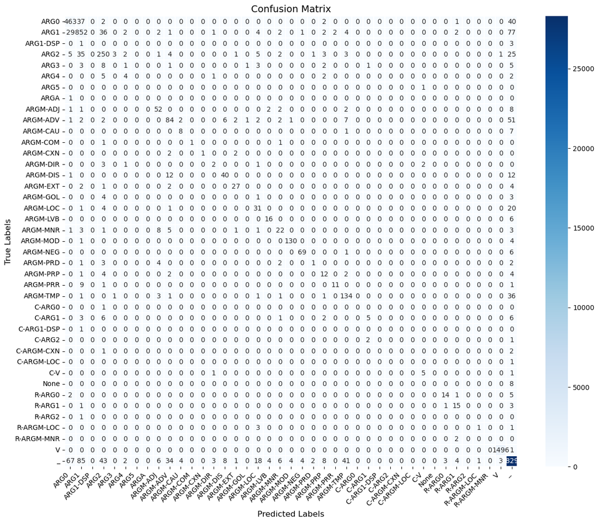

```python
evaluate(gold, pred)
```

**Model's preformance and comparison**

The confusion matrix shows that most accurate recalls occur among V and *. The model is highly confident in detecting predicates (V) and non-argument tokens (*), which dominate the dataset. Low-support labels such as C-ARG1 and R-ARGM-LOC have relatively high precision but suffer from poor recall. Classes with decent accurate recall, ARG0 and ARG1 have false negative and false positive cases that show a patter that the model is potential to confuse these two classes. Among all classes, majority of the false negatives are predicted as non-argument (_).

## SRL on Standalone Sentences

```python
# save the model
model.save_pretrained("bert_model_trained")
```

```python
# save the tokenizer
tokenizer.save_pretrained("Tokenizer_saved")
```

```
('Tokenizer_saved\\tokenizer_config.json',
 'Tokenizer_saved\\special_tokens_map.json',
 'Tokenizer_saved\\vocab.txt',
 'Tokenizer_saved\\added_tokens.json',
 'Tokenizer_saved\\tokenizer.json')
```

```python
# load the model and the tokenizer
# assuming that the model and tokenizer folders are in the same directory as this notebook
saved_model = AutoModelForTokenClassification.from_pretrained("bert_model_trained")
saved_tokenizer = AutoTokenizer.from_pretrained("Tokenizer_saved")
```

```python
# save the trainer
# with open("BERT_trainer.pkl", "wb") as trainer_file:
#     pickle.dump(trainer, trainer_file)
```

```python
# run this function before loading the trainer
def compute_metrics(p):
    """
    Compute evaluation metrics for token classification predictions.

    This function calculates precision, recall, f1 score, and accuracy for token-level
    predictions. It handles special tokens by removing ignored indices (-100) before computation.

    Argument:
        p (tuple): A tuple containing:
            - predictions (numpy.ndarray): model predictions with shape (batch_size, sequence_length, num_labels)
            - labels (numpy.ndarray): ground truth labels with shape (batch_size, sequence_length)
                Special tokens are marked with -100 and will be ignored in evaluation

    Returns:
        dict: A dictionary containing the following metrics:
            - precision (float): overall precision across all classes
            - recall (float): overall recall across all classes
            - f1 (float): overall f1 score across all classes
            - accuracy (float): overall accuracy across all classes

    Notes:
        - The function expects label_list to be defined in the outer scope
        - The metric object should be defined in the outer scope and support the
          compute() method with predictions and references parameters
        - Predictions are converted from logits to label indices using argmax
        - Special tokens (labeled as -100) are removed before metric computation
    """
    predictions, labels = p
    predictions = np.argmax(predictions, axis=2)

    # Remove ignored index (special tokens)
    true_predictions = [
        [label_list[p] for (p, l) in zip(prediction, label) if l != -100]
        for prediction, label in zip(predictions, labels)
    ]
    true_labels = [
        [label_list[l] for (p, l) in zip(prediction, label) if l != -100]
        for prediction, label in zip(predictions, labels)
    ]

    results = metric.compute(predictions=true_predictions, references=true_labels)
    return {
        "precision": results["overall_precision"],
        "recall": results["overall_recall"],
        "f1": results["overall_f1"],
        "accuracy": results["overall_accuracy"],
    }
```

```python
# load the trainer
# with open("BERT_trainer.pkl", "rb") as trainer_file:
#     saved_trainer = pickle.load(trainer_file)
```

```python
def mega_function(sentence_data, saved_tokenizer):
    """
    This is a function combining key components of functions including convert_df, augment_data, tokenized_input, preprocess_example, make_dataset.
    Specially designed for semantic role labeling using trained BERT model on standalone sentences.

    Parameters:
    sentence_data : pandas.DataFrame
        containing sentence-level data with the following columns:
        - 'word': tokens in the sentence.
        - 'predicate': binary integer indicators for predicates (1 means the token is a predicate, 0 means the token is not a predicate).
    saved_tokenizer: tokenizer added with special tokens

    Returns:
    tuple:
        - tokenized_data: list of dict
            A list of dictionaries where each dictionary contains the following keys:
            - 'input_ids'
            - 'attention_mask'
            - 'word_ids'
            - 'tokenized_tokens'
        - final_dataset: datasets.Dataset
            A Hugging Face Dataset object containing the tokenized input data for model training, containing:
            - 'input_ids'
            - 'attention_mask'
    """
    x = [
            {
                # 'id': '1',
                'tokens': sentence_data['word'].tolist(),
                'predicate': [0 if val == '_' else 1 for val in sentence_data['predicate']]
                # 'pred_word': sentence_data['pred_word'].tolist()
            }
        ]

    y = []
    for sentence in x:

        tokens = sentence['tokens']
        predicate = sentence['predicate']
        # pred_word = sentence['pred_word']

        # Process tokens based on the predicates
        processed_tokens = []
        processed_labels = []
        processed_predicate = []
        # processed_pred_word = []
        for idx, (token, pred) in enumerate(zip(tokens, predicate)):
            if pred == 1:
                processed_labels.append(-100) # if pred == 1, it will be recognized as a special token
                processed_predicate.append(predicate[idx])
                # processed_pred_word.append(pred_word[idx])
                processed_tokens.append("[PRED]")

            processed_tokens.append(token)
            processed_labels.append(labels[idx])
            processed_predicate.append(predicate[idx])
            # processed_pred_word.append(pred_word[idx])

        y.append({
            'tokens':processed_tokens,
            'labels': processed_labels
            # 'pred_word': processed_pred_word
        })

    tokenized_data=[]
    for sent in y:
        single_sent={}
        tokenized_input = saved_tokenizer(sent["tokens"], is_split_into_words=True)
        tokens = saved_tokenizer.convert_ids_to_tokens(tokenized_input["input_ids"])
        word_ids = tokenized_input.word_ids()

        single_sent["input_ids"] = tokenized_input["input_ids"]
        single_sent["attention_mask"] = tokenized_input["attention_mask"]
        single_sent['word_ids'] = word_ids
        single_sent['tokenized_tokens'] = tokens
        tokenized_data.append(single_sent)


    processed_data = []
    for example in tokenized_data:
        processed_data.append({
            "input_ids": tokenized_data[0]["input_ids"],
            "attention_mask": tokenized_data[0]["attention_mask"],
        })


    final_dataset = Dataset.from_dict({
        'input_ids': [example['input_ids'] for example in processed_data],
        'attention_mask': [example['attention_mask'] for example in processed_data]
    })

    return tokenized_data, final_dataset
```

```python
def transform_to_test_sentence(sent, target, trainer, saved_model, saved_tokenizer):
    """

    Parameters:
    sent (list of strings): tokens of a sentence.
    target (list of strings): list containing '0' and '1' as marking predicate. '1' means the token is a predicate.
    trainer
    saved_model
    saved_tokenizer: custom tokenizer with added special tokens

    Returns:
    A list of dictionaries of predictions.
    """

    if len(sent) != len(target):
        raise ValueError(
            "The length of the sentence and the array to mark predicate must be the same.")

    # creates list of dicts for word and predicate
    test_sentence = []
    for token, label in zip(sent, target):
        test_sentence.append(
            {"word": token, "predicate": token if label == "1" else '_'})

    # converts list of dicts to dataframe
    sentence_data = pd.DataFrame(test_sentence)
    tokenized_data, final = mega_function(sentence_data, saved_tokenizer)

    print(tokenized_data)
    predictions, _, _ = trainer.predict(final)
    predictions = np.argmax(predictions, axis=2)

    for idx, i in enumerate(tokenized_data):
        # slice the predictions to match the actual length of the sentence (ignoring padding tokens)
        length = len(i['word_ids'])
        i['predictions'] = predictions[idx][:length] # assign the model's predicted labels for this sentence

    processed_predictions = []
    for data in tokenized_data:
        word_ids = data['word_ids']
        predictions = data['predictions']

        # filter out elements where labels are -100
        word_ids = [b for a, b in zip(data['tokenized_tokens'], word_ids) if a not in ['[CLS]','[SEP]','[PAD]','[PRED]','[UNK]','[MASK]']]
        predictions = [b for a, b in zip(data['tokenized_tokens'], predictions) if a not in ['[CLS]','[SEP]','[PAD]','[PRED]','[UNK]','[MASK]']]

        predictions = [id2label[p] for p in predictions]

        # initialize variables to track the current group
        current_word_id = None
        current_predictions = []

        for idx, word_id in enumerate(word_ids):
            if word_id != current_word_id:
                # if a new word_id starts, calculate majority vote for the previous group
                if current_predictions:
                    processed_predictions.append(Counter(current_predictions).most_common(1)[0][0])

                # reset for the new word_id
                current_word_id = word_id
                current_predictions = [predictions[idx]]
            else:
                # add to the current group
                current_predictions.append(predictions[idx])

        # handle the last group
        if current_predictions:
            processed_predictions.append(Counter(current_predictions).most_common(1)[0][0])

    return processed_predictions


sent = ['She', 'had', 'an', 'uncontrollable', 'laugh', 'after', 'she', 'left', 'the', 'room','.']
sent_target = [0,0,0,1,0,0,0,1,0,0,0]

pred_arg = transform_to_test_sentence(sent, sent_target, trainer, saved_model, saved_tokenizer)
print(pred_arg)
```

```
[{'input_ids': [101, 2016, 2018, 2019, 4895, 8663, 13181, 4571, 3468, 4756, 2044, 2016, 2187, 1996, 2282, 1012, 102], 'attention_mask': [1, 1, 1, 1, 1, 1, 1, 1, 1, 1, 1, 1, 1, 1, 1, 1, 1], 'word_ids': [None, 0, 1, 2, 3, 3, 3, 3, 3, 4, 5, 6, 7, 8, 9, 10, None], 'tokenized_tokens': ['[CLS]', 'she', 'h…
['_', '_', '_', '_', '_', '_', '_', '_', '_', '_', '_']
```